# cdcperineq

Análisis de las desigualdades sociales en salud

Dante T. Castro Garro

2020-09-03

# Resumen

El paquete `cdcperineq` permite la visualización de las desigualdades sociales que asentúan los efectos de alguna enfermedad. El paquete ofrece dos tipos de análisis:

- Análisis por desigualdades.
- Análisis por brechas.

El presente manual solo pretende demostrar el uso de las funciones del paquete. Para la interpretación y análisis de la información se sugiere revisar el trabajo de Munayco et al. (2015)

# Data de prueba

`cdcperineq` viene con una data integrada que representa diferentes determinantes sociales a nivel de latinoamérica para diferentes periodos. Además, presenta información sobre la incidencia de tuberculosis, la cual será utilizada a manera de ejmplo.

```r
library(cdcperineq)
library(dplyr)
library(ggplot2)
library(cowplot)

glimpse(ineq_data)
```

```
#> Rows: 340
#> Columns: 23
#> $ id                   <int> 1, 2, 3, 4, 5, 6, 7, 8, 9, 10, 11, 12, 13, 14, 1…
#> $ year                 <int> 1995, 1996, 1997, 1998, 1999, 2000, 2001, 2002, …
#> $ country              <fct> Argentina, Argentina, Argentina, Argentina, Arge…
#> $ country_code         <fct> ARG, ARG, ARG, ARG, ARG, ARG, ARG, ARG, ARG, ARG…
#> $ population           <int> 35000000, NA, NA, NA, NA, 37000000, NA, NA, NA, …
#> $ wb_income_group      <fct> Upper middle income, Upper middle income, Upper …
#> $ wb_income_group_code <fct> WB_UMI, WB_UMI, WB_UMI, WB_UMI, WB_UMI, WB_UMI, …
#> $ gdp                  <int> 9590, 10000, 10700, 11000, 10500, 10300, 9730, 8…
#> $ gni                  <int> 9430, 9810, 10500, 10700, 10200, 10000, 9460, 79…
#> $ lexp                 <dbl> 73, 73, 73, 74, 74, 74, 74, 74, 75, 75, 75, 75, …
#> $ hexp                 <dbl> 649, 664, 754, 801, 851, 840, 828, 658, 717, 793…
#> $ ir_tb                <int> 49, 47, 45, 44, 42, 40, 39, 37, 36, 35, 33, 32, …
#> $ t_mort               <dbl> 3.2, 3.0, 2.9, 2.7, 2.5, 2.4, 2.3, 2.2, 2.1, 2.0…
#> $ t_jail               <int> 74, 94, 98, 99, 108, 112, 117, 152, 107, 131, 16…
#> $ urbgrow              <dbl> 1.63, 1.56, 1.54, 1.50, 1.45, 1.39, 1.28, 1.23, …
#> $ phiv                 <dbl> 0.3, 0.3, 0.3, 0.3, 0.3, 0.3, 0.3, 0.3, 0.3, 0.3…
#> $ impsfac              <int> 91, 90, 90, 90, 90, 91, 91, 90, 90, 90, 90, 90, …
#> $ impswt               <int> 95, 96, 96, 96, 96, 96, 96, 96, 96, 96, 96, 96, …
#> $ bcg                  <int> NA, NA, NA, NA, NA, NA, NA, NA, NA, NA, NA, NA, …
#> $ unemploy             <dbl> 18.8, 17.2, 14.9, 12.8, 14.1, 15.0, 18.3, 17.9, …
#> $ AIDS                 <dbl> 6.7, 8.2, 9.2, 6.5, 6.5, 6.6, 5.9, 6.1, 5.8, 5.4…
#> $ pnotified            <dbl> 0.7911765, 0.7880588, 0.7888125, 0.7672500, 0.88…
#> $ num_tb_cases         <dbl> 17000, 17000, 16000, 16000, 15000, 15000, 15000,…
```

Para el correcto uso de las funciones, la data debe tener un formato específico. Esto puede realizarse con la función `data_proc`. Este paso asegura también que el usuario sepa las variables que se utilizarán y el tipo de análisis.

# Funciones para el análisis de la desigualdad

En el siguiente ejemplo se evaluará la desgualdad para los años 2000, 2005 y 2010 para la tuberculosis en base a la esperanza de vida al nacer. La función requiere los años a analizar (`periodo`), el parámetro social (`vari.x`), la razón de incidencia (`vari.ir`) y la cantidad de casos de una enfermedad (`vari.num`). También es necesario especificar cuál es la columna que tiene los años (`year`), las regiones (`region`) y la cantidad de población (`población`).

```r
#
tabla = data_proc(
    data = ineq_data,
    tipo = 'desigualdad',
    periodo = c(2000, 2005, 2010),
    vari.x = 'lexp',
    vari.ir = 'ir_tb',
    vari.num = 'num_tb_cases',
    anhos = 'year',
    region = 'country',
    poblacion = 'population')
```

A partir de `tabla` se pueden hacer algunos gráficos como la desgiualdad social

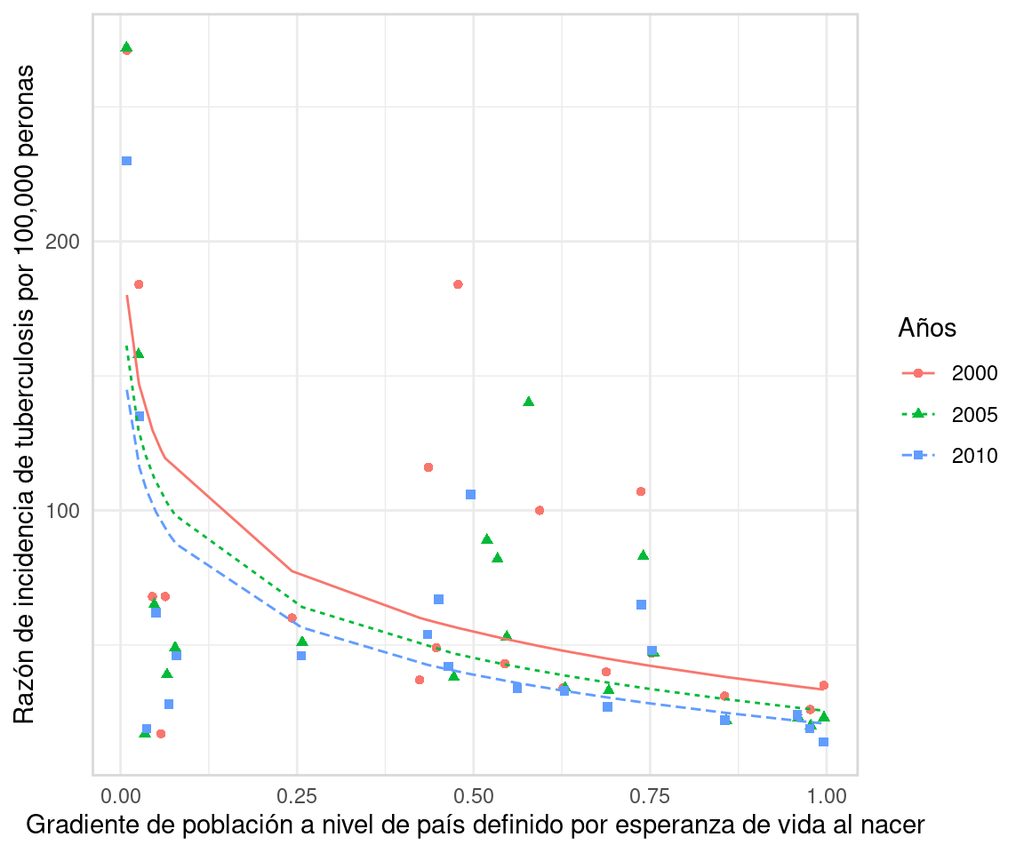

```r
ineq_gra(
    data = tabla,
    xlab = 'Gradiente de población a nivel de país definido por esperanza de vida al nacer',
    ylab = 'Razón de incidencia de tuberculosis por 100,000 peronas')
```

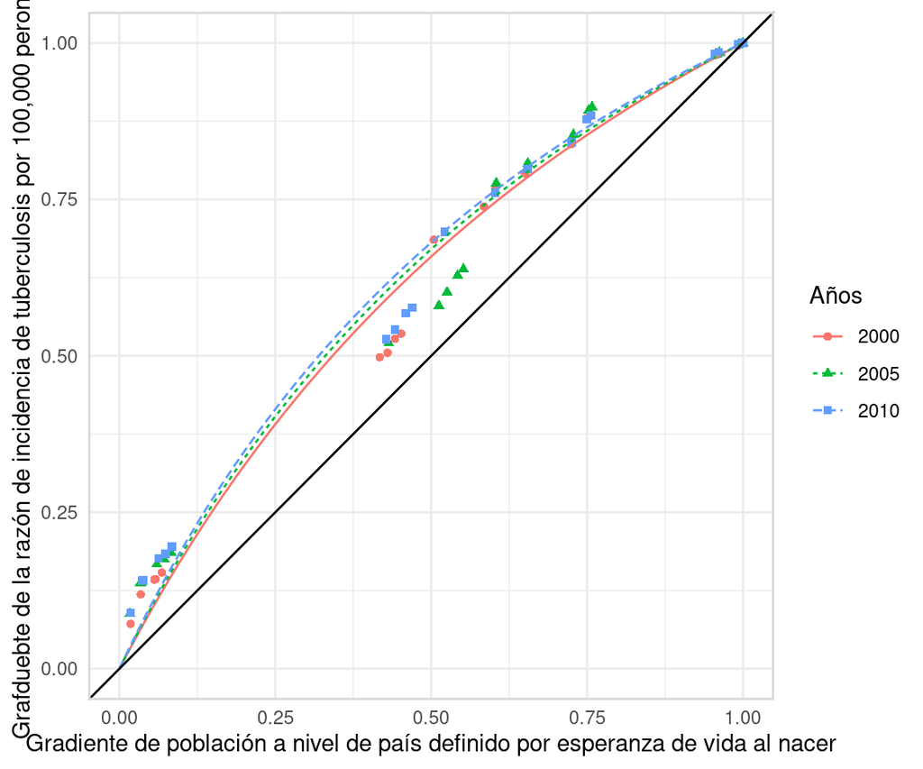

```r
ineq_reg(
    data = tabla,
    xlab = 'Gradiente de población a nivel de país definido por esperanza de vida al nacer',
    ylab = 'Grafduebte de la razón de incidencia de tuberculosis por 100,000 peronas')
```

o tablas con estadísticas que pueden complementar el análisis.

```r
ineq_tab(tabla)
```

```
#> # A tibble: 3 x 2
#>    year slope
#>   <int> <dbl>
#> 1  2000 -71.8
#> 2  2005 -65.5
#> 3  2010 -60.6
```

Ambas funciones son muy fáciles de utilizar.

# Funciones para el análisis de las brechas

El procedimiento es prácticamente el mismo que el realizado para el análisis de la desigualdad. Las diferencias están en indicarle a `data_proc` que ordene la data según el formato de brechas.

```r
tabla = data_proc(
    data = ineq_data,
    tipo = 'brecha',
    periodo = c(2000, 2005, 2010),
    vari.x = 'lexp',
    vari.ir = 'ir_tb',
    vari.num = 'num_tb_cases',
    anhos = 'year',
    region = 'country',
    poblacion = 'population')
```

Para realizar las gráficas y tablas, las funciones son similares al de desigualdades, solo que con un nombre diferente.

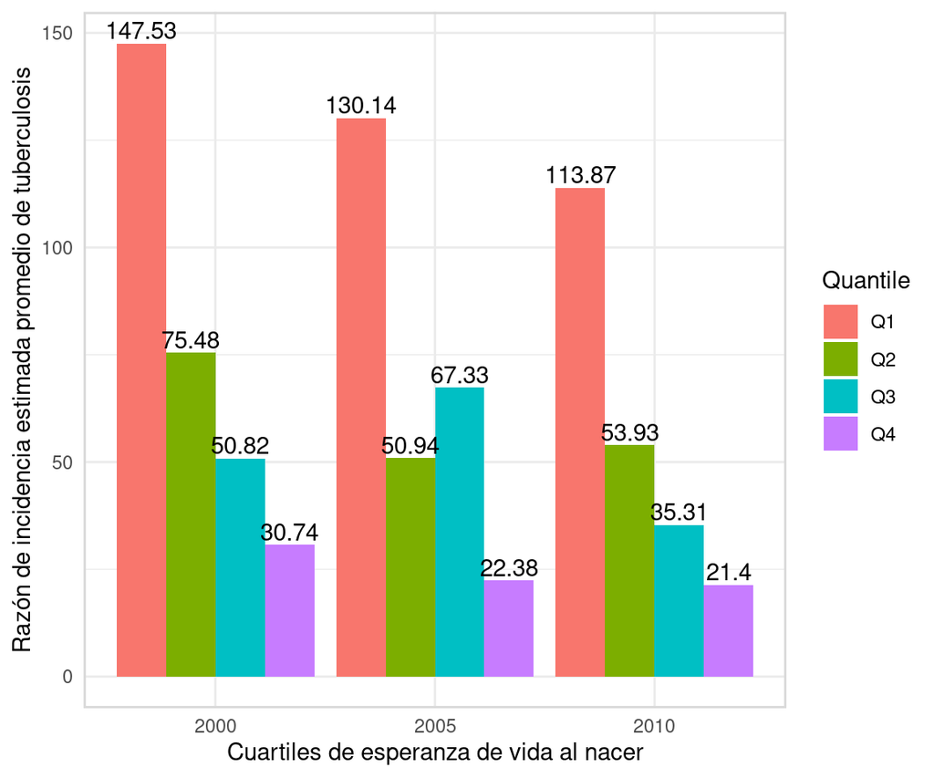

```r
brecha_gra(
    data = tabla,
    xlab = 'Cuartiles de esperanza de vida al nacer',
    ylab = 'Razón de incidencia estimada promedio de tuberculosis')
```

```r
brecha_tab(tabla)
```

```
#> # A tibble: 3 x 4
#>    year regional_mean_rate absolute_Kuznets_index relative_Kuznets_index
#>   <int>              <dbl>                  <dbl>                  <dbl>
#> 1  2000               63.1                  117.                    4.80
#> 2  2005               52.8                  108.                    5.81
#> 3  2010               46.0                   92.5                   5.32
```

# Web App

El paquete también incluye una función que permite visualizar la información disponible de manera interactiva.

```r
# Parámetros sociales
soc_var = c(
    'Esperanza de vida' = 'lexp',
    'Gasto en salud' = 'hexp',
    'Acceso a instalaciones mejoradas de saneamiento' = 'impsfac',
    'Tasa de detección de tuberculosis' = 'pnotified')

# Parámetros de salud
salud = list('Tuberculosis' = c(IR = 'ir_tb', Num = 'num_tb_cases'))

# Años de análisis
years = c(2000, 2005, 2010)

# Web app
desi_app(
    data = ineq_data,
    salud = salud,
    social = social,
    years = years)
```

# Referencias

Munayco, Cesar, Oscar Mújica, Francisco León, Mirtha Granado, and Marcos Espinal. 2015. “Social Determinants and Inequalities in Tuberculosis Incidence in Latin America and the Caribbean.” *Revista Panamericana de Salud Pública* 38 (September): 177–85.